# DV_RProject3

Monica and Rachel

October 28, 2015

## **Part 1 Extracting Data and Transforming into SQL Statement**

For our project, we extracted statistics from different A schools, Elementaries, Middle Schools, and High Schools in Colorado in 2011.

Our table displays the different schools and their varying Math, Reading, and Writing grades as well as their growth rates.

The code that we used to extract, transform, and load the data into an sql statement is as follows:

```r
source("../01 Data/ETL.R")
```

```
## 'data.frame':    2069 obs. of  26 variables:
##  $ SCHOOLNAME                   : chr  "BEAR CREEK ELEMENTARY SCHOOL" "CHERRY HILLS VILLAGE ELEMENTARY SCHOOL" "CHEYENNE MOUNTAIN ELEMENTARY SCHOOL" "CHINOOK TRAIL ELEMENTARY SCHOOL" ...
##  $ DISTrictNUMBER               : int  480 130 1020 1040 1040 880 130 880 1560 1420 ...
##  $ DISTRICTNAME                 : chr  "BOULDER VALLEY RE 2" "CHERRY CREEK 5" "CHEYENNE MOUNTAIN 12" "ACADEMY 20" ...
##  $ EMH                          : chr  "E" "E" "E" "E" ...
##  $ EMH_Combined                 : chr  "" "" "" "" ...
##  $ SCHOOLNUMBER                 : int  652 1574 1586 1615 1630 1908 1916 2027 2089 5758 ...
##  $ AEC_10                       : int  0 0 0 0 0 0 0 0 0 0 ...
##  $ Charter                      : int  0 0 0 0 1 0 0 0 0 0 ...
##  $ Online                       : int  0 0 0 0 0 0 0 0 0 0 ...
##  $ INITIAL_PlanType             : chr  "Performance Plan" "Performance Plan" "Performance Plan" "Performance Plan" ...
##  $ FINAL_PlanType               : chr  "Performance Plan" "Performance Plan" "Performance Plan" "Performance Plan" ...
##  $ Notes                        : chr  "" "" "" "" ...
##  $ EMH_2lvl                     : int  1 1 1 1 2 1 1 1 1 1 ...
##  $ LT100pnts                    : int  0 0 0 0 0 0 0 0 0 0 ...
##  $ School_Grade                 : int  13 13 13 13 13 13 13 13 13 13 ...
##  $ rank_tot                     : int  1 1 1 1 1 1 1 1 1 1 ...
##  $ Overall_ACH_Grade            : int  13 12 13 12 13 12 12 13 12 12 ...
##  $ Read_Ach_Grade               : int  12 12 12 12 13 12 12 13 12 12 ...
##  $ Math_Ach_Grade               : int  13 12 12 12 12 13 13 13 13 12 ...
##  $ Write_Ach_Grade              : int  12 13 13 12 12 12 12 13 11 10 ...
##  $ Sci_Ach_Grade                : int  12 12 12 11 13 12 12 13 12 11 ...
##  $ Overall_Weighted_Growth_Grade: int  13 13 12 13 10 12 13 12 13 13 ...
##  $ Read_Growth_Grade            : int  12 13 9 12 9 13 13 12 13 12 ...
##  $ Math_Growth_Grade            : int  12 12 10 13 9 10 12 10 13 12 ...
##  $ Write_Growth_Grade           : int  12 13 12 9 10 11 12 10 13 12 ...
##  $ SPF_PS_IND_GRAD_RATE         : chr  "" "" "" "" ...
## CREATE TABLE 2011_final_grade (
## -- Change table_name to the table name you want.
##  SCHOOLNAME varchar2(4000),
##  DISTRICTNAME varchar2(4000),
##  EMH varchar2(4000),
##  EMH_Combined varchar2(4000),
##  INITIAL_PlanType varchar2(4000),
##  FINAL_PlanType varchar2(4000),
##  Notes varchar2(4000),
##  DISTrictNUMBER number(38,4),
##  SCHOOLNUMBER number(38,4),
##  AEC_10 number(38,4),
##  Charter number(38,4),
##  Online number(38,4),
##  EMH_2lvl number(38,4),
##  LT100pnts number(38,4),
##  School_Grade number(38,4),
##  rank_tot number(38,4),
##  Overall_ACH_Grade number(38,4),
##  Read_Ach_Grade number(38,4),
##  Math_Ach_Grade number(38,4),
##  Write_Ach_Grade number(38,4),
##  Sci_Ach_Grade number(38,4),
##  Overall_Weighted_Growth_Grade number(38,4),
##  Read_Growth_Grade number(38,4),
##  Math_Growth_Grade number(38,4),
##  Write_Growth_Grade number(38,4),
##  SPF_PS_IND_GRAD_RATE number(38,4)
##  );
```

## **Part 2 Finding additional datasets**

We used an additional table describing the different ethnic groups working at the schools with the code below.

```r
source("../01 Data/ETL_3.R")
```

```
## 'data.frame':    1798 obs. of  12 variables:
##  $ Org_Code         : int  10 10 10 10 10 10 10 10 10 10 ...
##  $ Organization_Name: chr  "MAPLETON 1" "MAPLETON 1" "MAPLETON 1" "MAPLETON 1" ...
##  $ School_Code      : int  187 212 263 309 501 502 503 504 505 506 ...
##  $ School_Name      : chr  "MAPLETON EXPEDITIONARY SCHOOL OF THE ARTS" "FRONT RANGE EARLY COLLEGE" "GLOBAL LEADERSHIP ACADEMY" "SKYVIEW ACADEMY HIGH SCHOOL" ...
##  $ TOTAL            : int  543 174 447 311 385 421 740 299 454 360 ...
##  $ PCT_AmInd        : num  0.01289 0.03448 0.00224 0.00322 0.01299 ...
##  $ PCT_Asian        : num  0.00552 0.00575 0 0.03215 0.01039 ...
##  $ PCT_Black        : num  0.03315 0.02874 0.02685 0.01286 0.00519 ...
##  $ PCT_hisp         : num  0.573 0.569 0.85 0.711 0.797 ...
##  $ PCT_White        : num  0.344 0.351 0.11 0.235 0.161 ...
##  $ PCT_PI           : num  0.00184 0 0 0 0 ...
##  $ PCT_2ormore      : num  0.02947 0.01149 0.01119 0.00643 0.01299 ...
## CREATE TABLE 2011_enrl_working (
## -- Change table_name to the table name you want.
##  Organization_Name varchar2(4000),
##  School_Name varchar2(4000),
##  Org_Code number(38,4),
##  School_Code number(38,4),
##  TOTAL number(38,4),
##  PCT_AmInd number(38,4),
##  PCT_Asian number(38,4),
##  PCT_Black number(38,4),
##  PCT_hisp number(38,4),
##  PCT_White number(38,4),
##  PCT_PI number(38,4),
##  PCT_2ormore number(38,4)
##  );
```

## **Part 3 Re-creating the plots in R Studio**

Using R Studio, we extracted the data from Oracle and created three different types of plots for our dataset.

*The first plot we created was a scatter plot.* This plot shows the relationship between the School Performance Framework graduation rate and the ranking of the schools. We can see from the graph that as the ranking of the school goes up (value goes down), the graduation rate of the schools increases. The color of the graph represents different Plantypes of the different schools. We can see from the graph that there is a cluster of Performance Plan type schools near the higher ranking schools and the higher graduation rates. Thus, we can conclude from this graph that schools with the Performance Plan tend to have higher rankings as well as higher graduation rates.

```
## Registering fonts with R
```

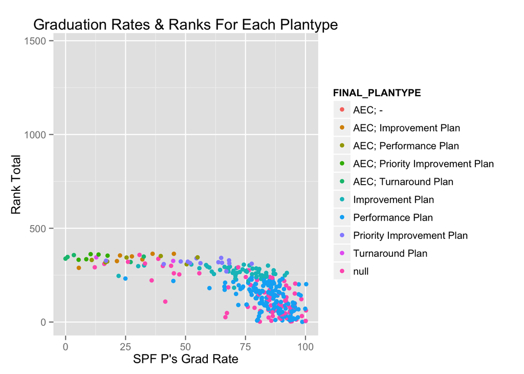

```r
source("../03 R SQL Visualisations/Scatter Plot.R")
```

*The second plot we created was a crosstab.* This graph displays information concerning the district name and the type of school (A schools, elementary, middle school, high school). The colors of the crosstab are adjustable KPIs that label whether the school is a ‘Great’, ‘Average’, or ‘Ok’ school based on rank. Any school under the ranking of 1000 is considered ‘Great’. Any school between 1000 and 10000 is considered ‘Average’, and all others are considered ‘Ok’. We can see that most A schools and high schools tend to be in the ‘Great’ label, while other schools tend to vary between the three categories.

```r
source("../03 R SQL Visualisations/Crosstab.R")
```

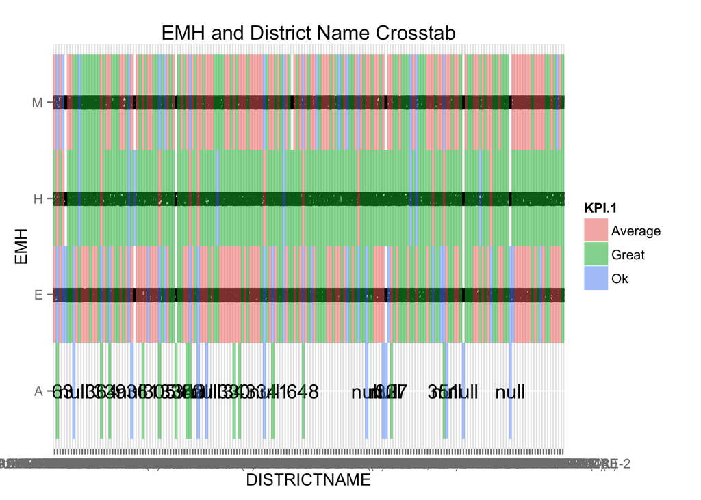

However, because our crosstab had too many results, the numbers merged together and it was difficult to read. Thus, we also created a graph that only displays the color of the KPI for each EMH and District Name.

```r
source("../03 R SQL Visualisations/Crosstab_NoLabel.R")
```

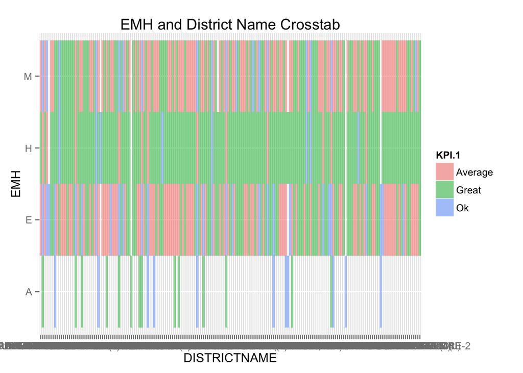

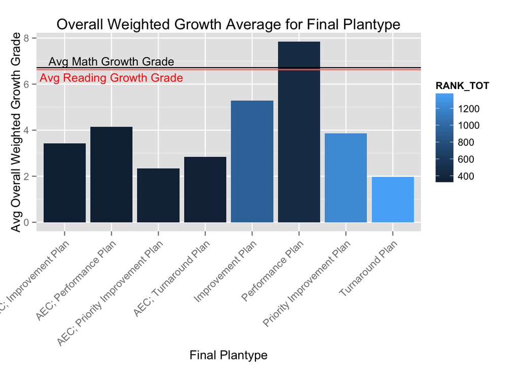

```r
source("../03 R SQL Visualisations/Bar Chart.R")
```

## **Part 4 Blending Data**

We blended two tables together to create new results. The tables we used consisted of the original table as well as another table depicting different ethnic groups within the school.

*Tableau*  
In Tableau, we combined the two datasets connected by the school name. We filtered out the schools so that only schools in the district name: “Aspen 1” were included in the graph. Then, we looked at a bar chart of the schools in the district and their correspending math growth scores. We then colored the graph with the percentage of Asians in the schools. From the graph, we can see that the school that grew the most in math scores consisted of less Asians.

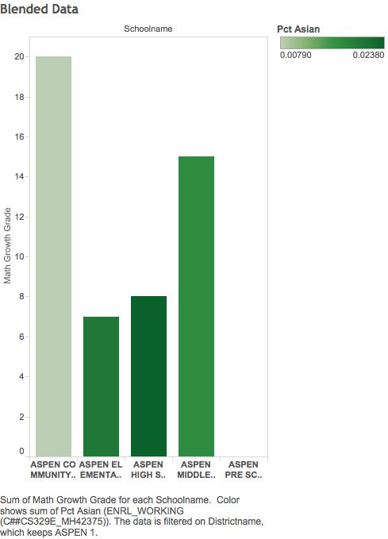

*R/SQL*

In SQL, we got both of the data sets from Oracle. In R, we combined the two datasets connected by the school code. We filtered out the schools so that only schools in the district name: “Aspen 1” were included in the graph. Then, we looked at a bar chart of the schools in the district and their correspending math growth scores. We then colored the graph with the percentage of Asians in the schools. From the graph, we can see that the school that grew the most in math scores consisted of less Asians.

```r
source("../03 R SQL Visualisations/BlendingRSQL.R")
```

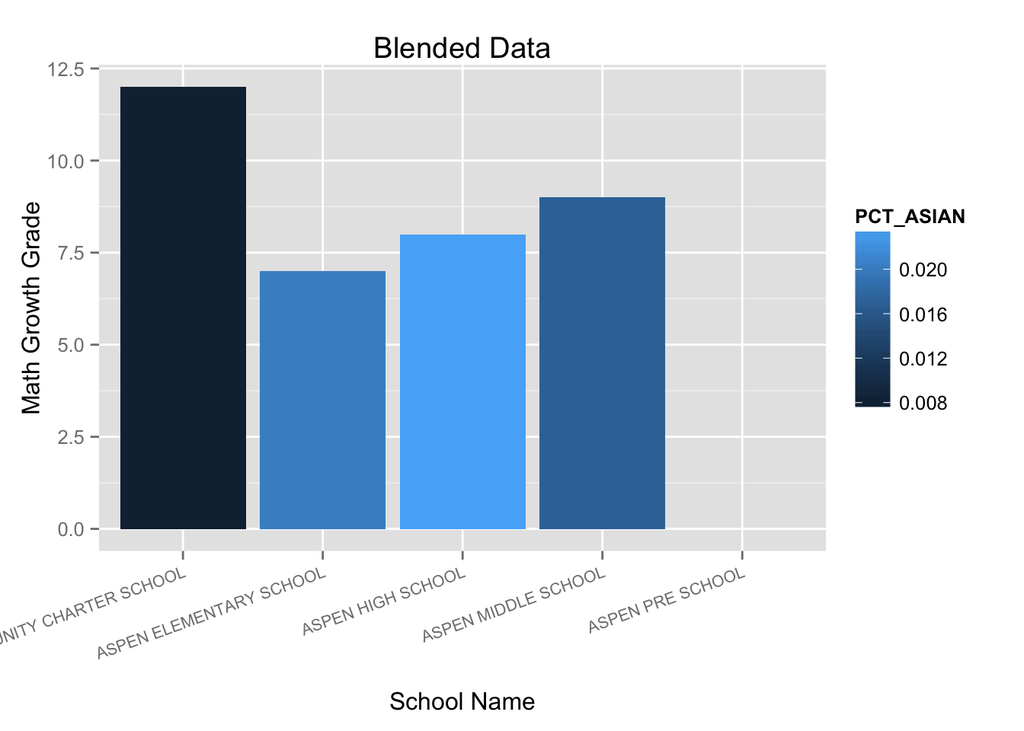